# In Praise of Documentation

# tl;dr

Please document your code.

# How I learned to love documentation

[figure not shown]

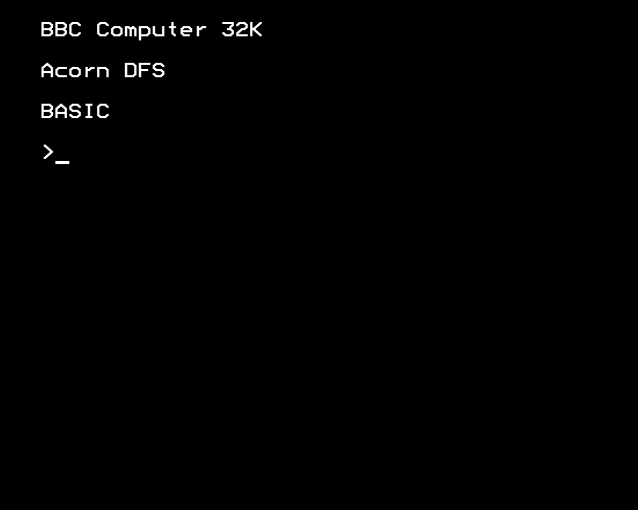

[figure not shown]

[figure not shown]

# The perils of poor documentation

# Why document your code

“Documentation is an often overlooked aspect of data science. It’s commonly left until the end of a project, but then you’re excited to move on to a new project, and the documentation is rushed or omitted completely. However, … documentation is a crucial part of making your code reproducible. If you want other people to use your code, or if you want to come back to your code in the future, it needs good documentation. It’s impossible to remember all your thoughts from when you originally wrote the code or initially carried out the experiments, so they need to be recorded.” (Nelson 2024)

# Types of documentation

“*Names*: Names of variables, functions, and files should be informative, an appropriate length, and easy to read.

*Comments*: Your comments should add extra information not contained in the code, such as a summary or a caveat.

*Docstrings*: Your functions should always have a docstring that describes the inputs and outputs of the function, as well as the purpose of that function.”

Nelson (2024)

# Types of documentation

“*READMEs*: Every repository or project should have an introduction that advertises your code and lets other people know why they should use it.

*Experiment tracking*: Experiments, especially in machine learning projects, should be tracked in a structured way.”

**Jupyter notebooks**: **Your notebooks will be much easier to read if you give them good names, give them a structure, and intersperse text and code.**”

Nelson (2024)

# History of literate programming

- A document formatting language
- A programming language

Knuth (1984)

# History of literate programming

**WEB** system:

- A document formatting language (TeX)
- A programming language (PASCAL)

Knuth (1984)

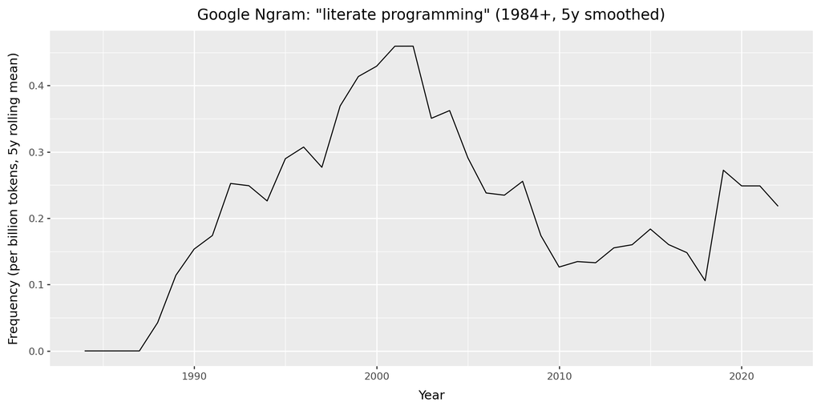

Google Ngram plot for literate programming (1984+, 5y smoothed)

Google Ngram: "literate programming"

Decade patterns (1984–2019), per-billion tokens

Decade

Trend (yearly)

Mean

Max

Max year

Years

1980s

[figure not shown]

0.095

0.357

1989

6

1990s

[figure not shown]

0.320

0.659

1998

10

2000s

[figure not shown]

0.268

0.594

2000

10

2010s

[figure not shown]

0.216

0.970

2019

10

# History of literate programming

The original **WEB** system was designed as a “tool for systems programmers, not for high school students or hobbyists”, because the programmer needs to be “comfortable dealing with multiple languages simultaneously” (Knuth 1984).

# Jupyter notebooks

“Notebooks — documents integrating prose, code and results — offer a way to publish a computational method which can be readily read and replicated.”

“Prose text can be interleaved with the code and output in a notebook to explain and highlight specific parts, forming a rich computational narrative.”

(Kluyver et al. 2016)

# Limitations of Jupyter

Pimentel et al. (2019) analysed 1.4 million notebooks on GitHub and found that out of 863,878 attempted executions of valid notebooks (i.e., notebooks with defined Python version and execution order):

- Only 24.11% executed without errors
- Only 4.03% produced the same results

They make recommendations for improving the use of Jupyter notebooks.

# Solutions to limitations

- [Jupytext](https://jupytext.readthedocs.io/en/latest/)
- [Marimo](https://marimo.io/) notebooks
- Nelson recommends using Jupyter notebooks for development work, before refactoring notebooks into modularised Python scripts with accompanying tests (Nelson 2024).

# R Markdown and Quarto

- [`knitr`](https://yihui.org/knitr/)
- [R Markdown](https://rmarkdown.rstudio.com/)
- [Quarto](https://quarto.org/)

# Quarto YAML

```
---
title: "In Praise of Documentation: Tools, Tips & Techniques for Literate Programming in the AI Age"
date: "2026-03-01"
categories: [documentation, talks]
format:
  html:
    toc: true
    code-fold: true
jupyter: pydata
bibliography: refs.bib
---
```

To render a Quarto document, use `quarto render` on the command line.

# Computer programs as literature

# Computer programs as literature

“I believe that the time is ripe for significantly better documentation of programs, and that we can best achieve this by considering programs to be *works of literature*” (Knuth 1984)

# Computer programs as literature

“Let us change our traditional attitude to the construction of progams. Instead of imagining that our main task is to instruct a *computer* what to do, let us concentrate rather on explaining to *human beings* what we want a computer to do” (Knuth 1984)

# Computer programs as literature

“The practitioner of literate programming can be regarded as an essayist, whose main concern is with exposition and excellence of style. Such an author, with thesaurus in hand, chooses the names of variables carefully and explains what each variable means. He or she strives for a program that is comprehensible because its concepts have been introduced in an order that is best for human understanding, using a mixture of formal and informal methods that reinforce each other” (Knuth 1984)

# Rules for good writing

[figure not shown]

George Orwell at the BBC in 1940

George Orwell (Orwell 1945) considered good writing to be active, precise, and simple.

He argued we should write actively rather than passively, be precise rather than vague, and use simple verbs rather than complex longer words or phrases.

If we can drop a word from a sentence without losing the meaning, we should drop it.

# Rules for good writing

[figure not shown]

George Orwell at the BBC in 1940

Orwell called the use of language a habit. And he made a close relationship between language and thought.

By learning to write well, we can develop good ways of thinking. By writing clearly, we can think clearly, and thereby communicate our thoughts more clearly to others.

The thoughts are in the words, and our thinking is displayed in our writing, so we had better choose our words wisely.

In writing well, we can feel more like a human being, rather than a machine.

# Documentation in the age of AI

# Documentation in the age of AI

- [Spec-driven development](https://en.wikipedia.org/wiki/Spec-driven_development)
- [AGENTS.MD](https://agents.md/)
- Coding agent CLI or IDE tools can be instructed to read the `AGENTS.md` and do “spec-driven development” (e.g. Claude Code, Cursor, OpenAI Codex).

# Concluding remarks

# Further Resources

To read a longer version of this talk, see the [blog post](https://www.carecodeconnect.io/posts/in-praise-of-documentation/) @ [carecodeconnect.io](https://www.carecodeconnect.io/).

[Diátaxis](https://diataxis.fr/): documentation framework.

[Great Docs](https://posit-dev.github.io/great-docs/): documentation site generator for Python packages.

[`man`](https://www.man7.org/linux/man-pages/man1/man.1.html): manual pages for Unix-like operating systems.

[Material for MkDocs](https://squidfunk.github.io/mkdocs-material/): MkDocs theme and extensions for fast, searchable, polished project docs.

[Pandoc](https://pandoc.org/): universal document converter.

[Quarto](https://quarto.org/): open source scientific and technical publishing system.

# Further Resources

[Read the Docs](https://readthedocs.org/): free hosting that builds and publishes documentation from your repository.

[Sphinx](https://www.sphinx-doc.org/): extensible documentation generator (reStructuredText-first) used widely in Python for multi-format technical docs.

[tldr](https://tldr.sh/): concise, community-driven, open-source help pages for command-line tools.

[Write the Docs](https://www.writethedocs.org/guide/): best practices for creating software documentation and technical writing.

[Zensical](https://zensical.org/): static site generator for Markdown documentation sites, from the same ecosystem as Material for MkDocs.

# References

Gazzard, A. 2016. *Now the Chips Are down: The BBC Micro*. The MIT Press.

Kluyver, T., B. Ragan-Kelley, F. Pérez, B. Granger, M. Bussonnier, J. Frederic, K. Kelley, et al. 2016. “Jupyter Notebooks – a Publication Format for Reproducible Computational Workflows.” In *Positioning and Power in Academic Publishing: Players, Agents and Agendas*, edited by F. Loizides and B. Schmidt.

Knuth, D. E. 1984. “Literate Programming.” *The Computer Journal* 27 (2): 97–111. https://doi.org/10.1093/comjnl/27.2.97.

Nelson, C. 2024. *Software Engineering for Data Scientists: From Notebooks to Scalable Systems*. O’Reilly.

Orwell, G. 1945. *Politics and the English Language*. London: Penguin Books.

Pimentel, J. F., L. Murta, V. Braganholo, and J. Friere. 2019. “A Large-Scale Study about Quality and Reproducibility of Jupyter Notebooks.” In *IEEE/ACM 16th International Conference on Mining Software Repositories*, 507–17. Montreal, QC, Canada. https://doi.org/10.1109/MSR.2019.00077.